# Tuần 3: Bài tập phân bố chuẩn

nguyenthithanhhuong

2024-02-28

#### **Bài 1:**

Tải tập dữ liệu **hills** trong thư viện **MASS**:

```r
library(MASS)
data <- hills
data
```

```
##                  dist climb    time
## Greenmantle       2.5   650  16.083
## Carnethy          6.0  2500  48.350
## Craig Dunain      6.0   900  33.650
## Ben Rha           7.5   800  45.600
## Ben Lomond        8.0  3070  62.267
## Goatfell          8.0  2866  73.217
## Bens of Jura     16.0  7500 204.617
## Cairnpapple       6.0   800  36.367
## Scolty            5.0   800  29.750
## Traprain          6.0   650  39.750
## Lairig Ghru      28.0  2100 192.667
## Dollar            5.0  2000  43.050
## Lomonds           9.5  2200  65.000
## Cairn Table       6.0   500  44.133
## Eildon Two        4.5  1500  26.933
## Cairngorm        10.0  3000  72.250
## Seven Hills      14.0  2200  98.417
## Knock Hill        3.0   350  78.650
## Black Hill        4.5  1000  17.417
## Creag Beag        5.5   600  32.567
## Kildcon Hill      3.0   300  15.950
## Meall Ant-Suidhe  3.5  1500  27.900
## Half Ben Nevis    6.0  2200  47.633
## Cow Hill          2.0   900  17.933
## N Berwick Law     3.0   600  18.683
## Creag Dubh        4.0  2000  26.217
## Burnswark         6.0   800  34.433
## Largo Law         5.0   950  28.567
## Criffel           6.5  1750  50.500
## Acmony            5.0   500  20.950
## Ben Nevis        10.0  4400  85.583
## Knockfarrel       6.0   600  32.383
## Two Breweries    18.0  5200 170.250
## Cockleroi         4.5   850  28.100
## Moffat Chase     20.0  5000 159.833
```

```r
names(data)
```

```
## [1] "dist"  "climb" "time"
```

a.Tìm giá trị trung bình và độ lệch tiêu chuẩn của độ dài các đường đua, độ cao đạt được và thời gian chạy của người chiến thắng.  
Giá trị trung bình của độ dài các đường đua:

```r
meanDist <- mean(data$dist)
meanDist
```

```
## [1] 7.528571
```

Độ lệch chuẩn của độ dài các đường đua:

```r
sdDist <- sd(data$dist)
sdDist
```

```
## [1] 5.523936
```

Giá trị trung bình của độ cao đạt được:

```r
meanClimb <- mean(data$climb)
meanClimb
```

```
## [1] 1815.314
```

Độ lệch chuẩn của độ cao đạt được:

```r
sdClimb <- sd(data$climb)
sdClimb
```

```
## [1] 1619.151
```

Giá trị trung bình thời gian chạy của người chiến thắng:

```r
meanTime <- mean(data$time)
meanTime
```

```
## [1] 57.87571
```

Độ lệch chuẩn thời gian chạy của người chiến thắng:

```r
sdTime <- sd(data$time)
sdTime
```

```
## [1] 50.04072
```

b.Các biến trong bộ dữ liệu có tuân theo phân phối chuẩn không?  
Độ dài các đường đua:

```r
shapiro.test(data$dist)
```

```
##
##  Shapiro-Wilk normality test
##
## data:  data$dist
## W = 0.74904, p-value = 2.362e-06
```

Kết luận: Do p-value < 0.05 nên độ dài các đường đua không tuân theo phân bố chuẩn.  
Độ cao đạt được:

```r
shapiro.test(data$climb)
```

```
##
##  Shapiro-Wilk normality test
##
## data:  data$climb
## W = 0.79245, p-value = 1.456e-05
```

Kết luận: Do p-value < 0.05 nên độ cao đạt được không tuân theo phân bố chuẩn.  
Thời gian chạy của người chiến thắng:

```r
shapiro.test(data$time)
```

```
##
##  Shapiro-Wilk normality test
##
## data:  data$time
## W = 0.73673, p-value = 1.458e-06
```

Kết luận: Do p-value < 0.05 nên thời gian chạy của người chiến thắng không tuân theo phân bố chuẩn.  
c.Dùng hàm pairs để vẽ ma trận biểu đồ tán xạ cho bộ dữ liệu:

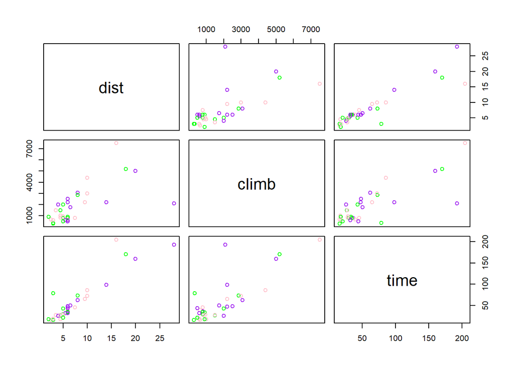

```r
pairs(
  data,
  col = c("pink", "purple", "green")
)
```

d.Có thể có biểu diễn tuyến tính của biến thời gian theo một hay hai biến còn lại? Vì sao? Đưa ra mô hình hồi quy tuyến tính phù hợp.

```r
lm.fit <- lm(data$time ~ data$dist + data$climb, data = hills)
lm.fit
```

```
##
## Call:
## lm(formula = data$time ~ data$dist + data$climb, data = hills)
##
## Coefficients:
## (Intercept)    data$dist   data$climb
##    -8.99204      6.21796      0.01105
```

Kết luận: Có thể biểu diễn tuyến tính biến thời gian theo hai biến còn lại.  
Mô hình hồi quy tuyến tính: **time = -8.99204 + 6.21796 * dist + 0.01105 * climb**  
e.Tính giá trị trung bình và phương sai của bình phương hiệu số giữa thời gian quan sát và thời gian dự đoán theo mô hình ở ý (d). Bình phương hiệu số đó có phân phối chuẩn không?  
Thời gian dự đoán theo mô hình ở ý (d):

```r
predictTime <- predict(lm.fit)
predictTime
```

```
##      Greenmantle         Carnethy     Craig Dunain          Ben Rha
##         13.73399         55.93547         38.25881         46.48096
##       Ben Lomond         Goatfell     Bens of Jura      Cairnpapple
##         74.66869         72.41492        173.35458         37.15402
##           Scolty         Traprain      Lairig Ghru           Dollar
##         30.93607         35.49684        188.31133         44.19356
##          Lomonds      Cairn Table       Eildon Two        Cairngorm
##         74.38394         33.83965         35.56063         86.33125
##      Seven Hills       Knock Hill       Black Hill       Creag Beag
##        102.36474         13.52860         30.03667         31.83546
##     Kildcon Hill Meall Ant-Suidhe   Half Ben Nevis         Cow Hill
##         12.97620         29.34267         52.62110         13.38699
##    N Berwick Law       Creag Dubh        Burnswark        Largo Law
##         16.29057         37.97560         37.15402         32.59325
##          Criffel           Acmony        Ben Nevis      Knockfarrel
##         50.75852         27.62169        101.79832         34.94444
##    Two Breweries        Cockleroi     Moffat Chase
##        160.38030         28.37949        170.60663
```

Giá trị trung bình và phương sai của bình phương hiệu số giữa thời gian quan sát và thời gian dự đoán theo mô hình ở ý (d):

```r
squaredDiffTime <- (hills$time - predictTime)^2
mean(squaredDiffTime)
```

```
## [1] 196.9105
```

```r
var(squaredDiffTime)
```

```
## [1] 523963.8
```

Bình phương hiệu số đó có phân phối chuẩn không?

```r
shapiro.test(squaredDiffTime)
```

```
##
##  Shapiro-Wilk normality test
##
## data:  squaredDiffTime
## W = 0.27219, p-value = 5.258e-12
```

Kết luận: Do p-value < 0.05 nên bình phương hiệu số trên không tuân theo phân bố chuẩn.

#### **Bài 2:**

Tải tập dữ liệu **iris** trong thư viện **datasets**:

```r
library(datasets)
data <- iris
data
```

```
##     Sepal.Length Sepal.Width Petal.Length Petal.Width    Species
## 1            5.1         3.5          1.4         0.2     setosa
## 2            4.9         3.0          1.4         0.2     setosa
## 3            4.7         3.2          1.3         0.2     setosa
## 4            4.6         3.1          1.5         0.2     setosa
## 5            5.0         3.6          1.4         0.2     setosa
## 6            5.4         3.9          1.7         0.4     setosa
## 7            4.6         3.4          1.4         0.3     setosa
## 8            5.0         3.4          1.5         0.2     setosa
## 9            4.4         2.9          1.4         0.2     setosa
## 10           4.9         3.1          1.5         0.1     setosa
## 11           5.4         3.7          1.5         0.2     setosa
## 12           4.8         3.4          1.6         0.2     setosa
## 13           4.8         3.0          1.4         0.1     setosa
## 14           4.3         3.0          1.1         0.1     setosa
```

[output cut: 136 more lines]

```r
names(data)
```

```
## [1] "Sepal.Length" "Sepal.Width"  "Petal.Length" "Petal.Width"  "Species"
```

a.Tìm giá trị trung bình và độ lệch tiêu chuẩn của độ dài, độ rộng cánh hoa và đài hoa:

```r
mean(data$Petal.Length) # giá trị trung bình của độ dài cánh hoa
```

```
## [1] 3.758
```

```r
sd(data$Petal.Length) # độ lệch tiêu chuẩn của độ dài cánh hoa
```

```
## [1] 1.765298
```

```r
mean(data$Petal.Width) # giá trị trung bình của độ rộng cánh hoa
```

```
## [1] 1.199333
```

```r
sd(data$Petal.Width) # độ lệch tiêu chuẩn của độ rộng cánh hoa
```

```
## [1] 0.7622377
```

```r
mean(data$Sepal.Length) # giá trị trung bình của độ dài đài hoa
```

```
## [1] 5.843333
```

```r
sd(data$Sepal.Length) # độ lệch tiêu chuẩn của độ dài đài hoa
```

```
## [1] 0.8280661
```

```r
mean(data$Sepal.Width) # giá trị trung bình của độ rộng đài hoa
```

```
## [1] 3.057333
```

```r
sd(data$Sepal.Width) # độ lệch tiêu chuẩn của độ rộng đài hoa
```

```
## [1] 0.4358663
```

b.Các biến trong bộ dữ liệu có tuân theo phân phối chuẩn không?  
Độ dài cánh hoa:

```r
shapiro.test(data$Petal.Length)
```

```
##
##  Shapiro-Wilk normality test
##
## data:  data$Petal.Length
## W = 0.87627, p-value = 7.412e-10
```

Kết luận: Do p-value < 0.05 nên độ dài cánh hoa không tuân theo phân bố chuẩn.  
Độ rộng cánh hoa:

```r
shapiro.test(data$Petal.Width)
```

```
##
##  Shapiro-Wilk normality test
##
## data:  data$Petal.Width
## W = 0.90183, p-value = 1.68e-08
```

Kết luận: Do p-value < 0.05 nên độ rộng cánh hoa không tuân theo phân bố chuẩn.  
Độ dài đài hoa:

```r
shapiro.test(data$Sepal.Length)
```

```
##
##  Shapiro-Wilk normality test
##
## data:  data$Sepal.Length
## W = 0.97609, p-value = 0.01018
```

Kết luận: Do p-value < 0.05 nên độ dài đài hoa không tuân theo phân bố chuẩn.  
Độ rộng đài hoa:

```r
shapiro.test(data$Sepal.Width)
```

```
##
##  Shapiro-Wilk normality test
##
## data:  data$Sepal.Width
## W = 0.98492, p-value = 0.1012
```

Kết luận: Do p-value > 0.05 nên độ rộng đài hoa tuân theo phân bố chuẩn.  
c.Vẽ đồ thị hàm mật độ và hàm phân phối của các biến có phân phối chuẩn trên cùng một khung hình. Đặt tên đồ thị, tên và độ dài các trục phù hợp.  
Do độ rộng đài hoa (Sepal.Width) tuân theo phân bố chuẩn nên ta vẽ hàm mật độ và hàm phân bố của biến này:

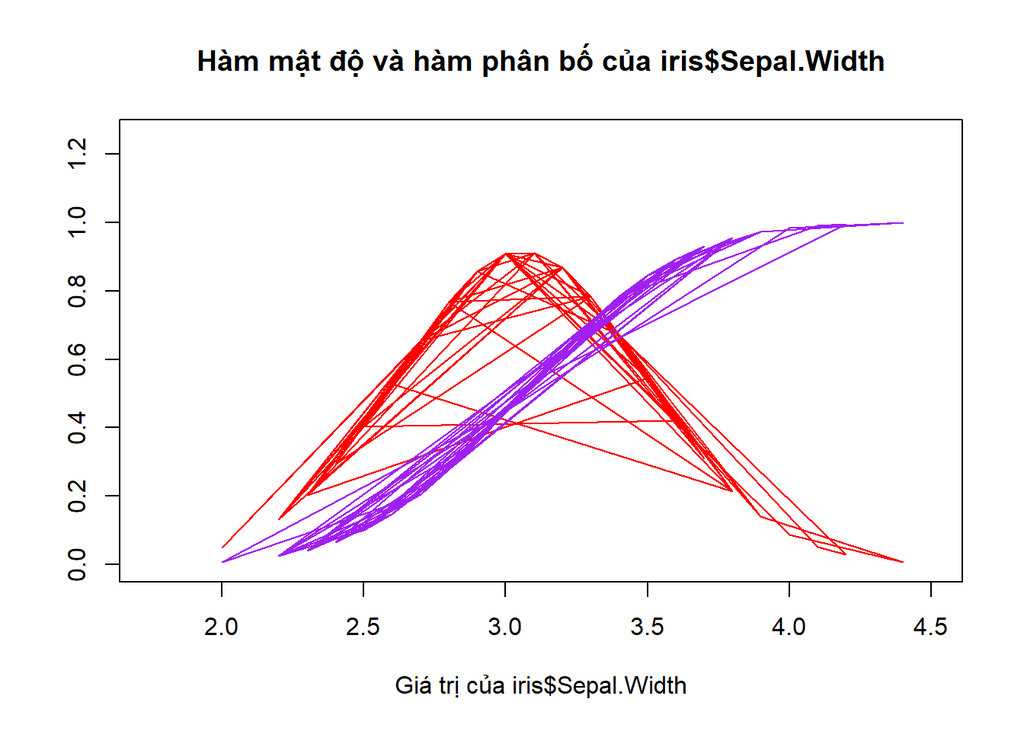

```r
plot(
  data$Sepal.Width,
  dnorm(
    data$Sepal.Width,
    mean(data$Sepal.Width),
    sd(data$Sepal.Width)
  ),
  xlab = "Giá trị của iris$Sepal.Width",
  ylab = "",
  xlim = c(1.75, 4.5),
  ylim = c(0, 1.25),
  col = "red",
  type = "l",
)
lines(
  data$Sepal.Width,
  pnorm(
    data$Sepal.Width,
    mean(data$Sepal.Width),
    sd(data$Sepal.Width)
  ),
  ylab = "",
  col = "purple"
)
title("Hàm mật độ và hàm phân bố của iris$Sepal.Width")
```

d.Với mức ý nghĩa 5%, có thể nói độ rộng trung bình của đài hoa nhỏ hơn 3.5 không?

```r
t.test(
  data$Sepal.Width,
  mu = 3.5,
  alt = "less",
  conf.level = 0.99
)
```

```
##
##  One Sample t-test
##
## data:  data$Sepal.Width
## t = -12.439, df = 149, p-value < 2.2e-16
## alternative hypothesis: true mean is less than 3.5
## 99 percent confidence interval:
##      -Inf 3.141024
## sample estimates:
## mean of x
##  3.057333
```

Kết luận: Do p-value < 0.05, nên với mức ý nghĩa 5% có thể kết luận giá trị trung bình của đài hoa nhỏ hơn 3.5  
e.Tìm a, biết xác suất để độ rộng đài hoa nhỏ hơn a là 70%.

```r
qnorm(
  0.70,
  mean = mean(data$Sepal.Width),
  sd = sd(data$Sepal.Width)
)
```

```
## [1] 3.285902
```

f.Độ rộng trung bình của đài hoa của loài setosa và versicolor có thực sự khác nhau không? Mức ý nghĩa 1%.

```r
setosa <- data$Sepal.Width[data$Species == "setosa"]
versicolor <- data$Sepal.Width[data$Species == "versicolor"]
t.test(
  setosa,
  versicolor,
  conf.level = 0.99)
```

```
##
##  Welch Two Sample t-test
##
## data:  setosa and versicolor
## t = 9.455, df = 94.698, p-value = 2.484e-15
## alternative hypothesis: true difference in means is not equal to 0
## 99 percent confidence interval:
##  0.4750576 0.8409424
## sample estimates:
## mean of x mean of y
##     3.428     2.770
```

Kết luận: Do p-value < 0.05 nên Độ rộng trung bình của đài hoa của loài setosa và versicolor thực sự khác nhau.